# Investigation of univariate analysis

Single-trait SNP clustering: each column is a GWAS SNP for the target trait, each row is a background study (phenotypic or molecular; no collapsing). Profiles are oriented, compressed, and clustered with **ebmf** (Louvain: signed modularity on the SNP similarity graph; EBMF: empirical Bayes matrix factorization with overlapping programs, hard-assigned to their strongest factor). Modules/programs are then validated with a filtering framework — internal coherence (mean internal similarity and connectedness), factor strength normalised by the square root of the number of filtered SNPs, and trait-subsampling stability — plus descriptive evidence scores (aggregate posterior evidence and factor distinctiveness) before interpretation.

Active run parameters

| api | gpmap_url | min_snp_signals | trait_subset | cluster_type | louvain_gamma | compress_method | compress_scale | include_trans | include_situated_gene | min_specificity | similarity_threshold | ebmf_se_mode | ebmf_beta_scale | ebmf_lfsr_threshold | ebmf_prior | ebmf_backfit | ebmf_magnitude_threshold | min_mean_internal | min_connectedness | n_null | alpha_membership | n_candidate_tier | n_rep | frac_traits | stability_top_n | stability_threshold | posterior_stat | posterior_evidence_cap | redundancy_threshold | … |
| --- | --- | --- | --- | --- | --- | --- | --- | --- | --- | --- | --- | --- | --- | --- | --- | --- | --- | --- | --- | --- | --- | --- | --- | --- | --- | --- | --- | --- | --- | --- |
| local | http://localhost:8000 | 2 | phenotypic | ebmf | 1.5 | asinh | 5 | TRUE | FALSE | 1.25 | 0.2 | unit | trait | 0.02 | point_laplace | TRUE | 0.75 | 0.3 | 0.5 | 10 | 0.05 | 25 | 3 | 0.8 | 20 | 0.5 | median | 50 | 0.9 | … |

## Step 1: Pleiotropy matrix

`build_pleiotropy_matrix()` builds z-scores (`beta / se`) at each target SNP. With `associations = "coloc"` it uses colocalisation rows only; with `associations = "full"` it uses all full associations (`/associations-full`). Molecular QTL studies stay as their own rows. When `include_trans = FALSE`, trans target markers are removed from the association rows before the matrix is built.

Pleiotropy matrix summary

| trait | n_rows | n_phenotypic | n_molecular | n_snps | fraction_non_na |
| --- | --- | --- | --- | --- | --- |
| Body mass index | 12460 | 2565 | 9895 | 970 | 0.003 |

## Step 1.5: Filter sparse and ubiquitous traits

Drop rows with fewer than `min_snp_signals` non-`NA` values, or with non-`NA` fraction above `max_snp_fraction` (target trait kept).

After sparse / ubiquitous trait filter

| min_snp_signals | max_snp_fraction | n_sparse_traits_removed | n_ubiquitous_traits_removed | n_traits_after | n_snps |
| --- | --- | --- | --- | --- | --- |
| 2 | 0.8 | 11458 | 0 | 1002 | 970 |

## Step 2: Orient and compress (X*)

## Step 3: SNP similarity (S)

Missing trait-SNP cells are treated as zero effects, preserving the original cosine similarity calculation.

SNP similarity summary

| n_snps | median_pairwise_overlap | fraction_pairs_eligible | min_similarity | max_similarity | mean_similarity |
| --- | --- | --- | --- | --- | --- |
| 970 | 3 | 1 | -0.89 | 1 | 0.35 |

## Step 4: Clustering

Edges with `|S| < similarity_threshold` are zeroed before Louvain. For EBMF, the oriented compressed matrix `X_star` is factorised directly (features x SNPs), a global mega-factor is dropped if detected, and each SNP is assigned to the factor with the largest absolute posterior loading among the factors it significantly belongs to.

## Step 4.5: Module / program validation

Both clustering paths share the same internal-coherence metrics, computed on the SNP similarity graph:

- **mean_internal_similarity** — mean off-diagonal `S` inside the module
- **separation** — internal minus external mean similarity
- **connectedness** — fraction of SNP pairs with `|S| >= similarity_threshold`

For EBMF, `summarise_ebmf_programs()` folds the graph-reliability metrics together with trait-subsampling **stability** and the descriptive **additional scores** into a single per-program table with pass/fail flags and an overall `status`:

- **factor_strength / factor_strength_per_snp** — proportion of observed matrix signal attributable to the factor (from its fitted reconstruction), computed on the lFSR/magnitude-filtered subset of EBMF-supported SNPs; `factor_strength_per_snp = factor_strength / sqrt(n_snps_filtered)`. Reported for context only; it does not gate `status`.
- **replication** — trait-subsampling stability: how often the top `stability_top_n` loading SNPs are recovered when `1 - frac_traits` of the traits are held out and flashier is refit (`n_rep` reruns, run in parallel on `cores` cores). Because this is expensive, it is only computed for programs that pass the internal-coherence checks; those programs must reach `replication >= stability_threshold`. Stability should use the same filtered SNP reference sets as the other program-level calculations, and the refitted programs are filtered with the same lFSR/magnitude thresholds.
- **posterior_evidence** — aggregate (`posterior_stat`) of `-log10(lfsr)` across assigned SNPs. Distinguishes programs dominated by borderline `lfsr ~ 0.05` memberships from programs whose memberships carry much stronger posterior sign evidence.
- **max_abs_factor_corr / redundant** — maximum absolute correlation of the program’s SNP loading vector with any other program; programs exceeding `redundancy_threshold` are flagged `redundant`.
- **max_pair_redundancy / most_redundant_program / redundancy_pass** — factor distinctiveness: for each program, the reciprocal SNP containment with every other program (`pair_redundancy = min(shared / n_snps_A, shared / n_snps_B)` on the assigned membership sets). The program fails (`redundancy_pass = FALSE`) when `max_pair_redundancy >= 0.9`, i.e. it captures essentially the same SNP set as another program.

A program is `valid` if it passes all four filters (`size`, `internal`, `stability`, `redundancy`); the failure reason is recorded in `status`.

All EBMF programs returned by flash, with each filter check. n_snps is the number of SNPs with nonzero EBMF support and n_snps_filtered is the subset surviving the lFSR/magnitude gate; factor_strength (as % of observed matrix signal) and factor_strength/sqrt(n_snps_filtered) are reported for context but do not gate status; replication is only checked for programs passing internal coherence (otherwise –); max_pair_redundancy is the reciprocal SNP containment with the most overlapping program (most_redundant_program), and redundancy_pass fails at >= 0.9; status is ‘valid’ or lists the failed checks (size; internal; stability; redundancy).

| program | n_snps | n_snps_filtered | mean_internal_similarity | connectedness | factor_strength_pct | factor_strength_per_snp_pct | replication | posterior_evidence | max_abs_factor_corr | redundant | max_pair_redundancy | most_redundant_program | redundancy_pass | size_pass | internal_pass | stability_pass | status |
| --- | --- | --- | --- | --- | --- | --- | --- | --- | --- | --- | --- | --- | --- | --- | --- | --- | --- |
| 1 | 970 | 270 | 0.595 | 0.961 | 40.18 | 2.445 | 0.85 | 50.00 | 0.599 | no | 0.293 | 2 | pass | pass | pass | pass | valid |
| 8 | 970 | 62 | 0.372 | 0.733 | 1.74 | 0.221 | 0.783 | 11.97 | 0.294 | no | 0.113 | 41 | pass | pass | pass | pass | valid |
| 4 | 970 | 49 | 0.404 | 0.832 | 1.26 | 0.180 | 0.8 | 50.00 | 0.210 | no | 0.204 | 27 | pass | pass | pass | pass | valid |
| 27 | 970 | 30 | 0.537 | 0.920 | 0.70 | 0.127 | 0.75 | 22.02 | 0.311 | no | 0.204 | 4 | pass | pass | pass | pass | valid |
| 41 | 970 | 29 | 0.328 | 0.643 | 0.66 | 0.123 | 0.55 | 7.00 | 0.251 | no | 0.241 | 49 | pass | pass | pass | pass | valid |
| 38 | 970 | 20 | 0.527 | 0.884 | 0.66 | 0.147 | 0.833 | 50.00 | 0.367 | no | 0.200 | 27 | pass | pass | pass | pass | valid |
| 22 | 970 | 18 | 0.427 | 0.928 | 0.63 | 0.147 | 0.926 | 17.65 | 0.181 | no | 0.182 | 42 | pass | pass | pass | pass | valid |
| 34 | 970 | 32 | 0.363 | 0.694 | 0.42 | 0.075 | 0.683 | 12.30 | 0.250 | no | 0.188 | 27 | pass | pass | pass | pass | valid |
| 39 | 970 | 50 | 0.541 | 0.921 | 0.32 | 0.045 | 0.683 | 7.02 | 0.299 | no | 0.200 | 27 | pass | pass | pass | pass | valid |
| 40 | 970 | 16 | 0.534 | 0.967 | 0.25 | 0.064 | 0.625 | 6.73 | 0.201 | no | 0.188 | 47 | pass | pass | pass | pass | valid |
| 7 | 970 | 8 | 0.513 | 0.821 | 0.14 | 0.051 | 0.5 | 50.00 | 0.599 | no | 0.125 | 12 | pass | pass | pass | pass | valid |
| 17 | 970 | 7 | 0.351 | 0.810 | 0.10 | 0.038 | 0.667 | 10.21 | 0.231 | no | 0.286 | 44 | pass | pass | pass | pass | valid |
| 20 | 970 | 4 | 0.437 | 0.500 | 0.03 | 0.016 | 0.917 | 32.48 | 0.222 | no | 0.250 | 46 | pass | pass | pass | pass | valid |
| 2 | 970 | 105 | 0.440 | 0.768 | 8.42 | 0.822 | 0.4 | 50.00 | 0.308 | no | 0.293 | 1 | pass | pass | pass | fail | stability |
| 3 | 970 | 8 | 0.051 | 0.786 | 3.85 | 1.363 | – | 50.00 | 0.678 | no | 0.375 | 5 | pass | pass | fail | n/a (not checked) | internal_similarity |
| 5 | 970 | 4 | -0.030 | 0.500 | 1.85 | 0.925 | – | 29.84 | 0.676 | no | 0.375 | 3 | pass | pass | fail | n/a (not checked) | internal_similarity |
| 6 | 970 | 1 | NA | NA | 1.26 | 1.258 | – | 50.00 | 0.062 | no | 0.010 | 2 | pass | fail | fail | n/a (not checked) | size; internal_similarity; connectedness |
| 32 | 970 | 11 | 0.113 | 0.509 | 1.25 | 0.377 | – | 50.00 | 0.678 | no | 0.364 | 3 | pass | pass | fail | n/a (not checked) | internal_similarity |
| 49 | 970 | 17 | 0.240 | 0.640 | 1.18 | 0.287 | – | 50.00 | 0.294 | no | 0.412 | 33 | pass | pass | fail | n/a (not checked) | internal_similarity |
| 13 | 970 | 53 | 0.244 | 0.539 | 1.17 | 0.161 | – | 23.39 | 0.402 | no | 0.190 | 2 | pass | pass | fail | n/a (not checked) | internal_similarity |
| 18 | 970 | 24 | 0.192 | 0.460 | 1.11 | 0.226 | – | 37.02 | 0.365 | no | 0.250 | 42 | pass | pass | fail | n/a (not checked) | internal_similarity; connectedness |
| 10 | 970 | 17 | 0.142 | 0.537 | 1.00 | 0.244 | – | 50.00 | 0.222 | no | 0.167 | 18 | pass | pass | fail | n/a (not checked) | internal_similarity |
| 42 | 970 | 22 | 0.227 | 0.498 | 0.99 | 0.212 | – | 25.58 | 0.397 | no | 0.250 | 18 | pass | pass | fail | n/a (not checked) | internal_similarity; connectedness |
| 19 | 970 | 9 | 0.293 | 0.556 | 0.90 | 0.300 | – | 10.51 | 0.099 | no | 0.222 | 17 | pass | pass | fail | n/a (not checked) | internal_similarity |
| 9 | 970 | 2 | 0.379 | 1.000 | 0.75 | 0.528 | – | 28.40 | 0.452 | no | 0.182 | 32 | pass | fail | fail | n/a (not checked) | size |
| 33 | 970 | 17 | 0.188 | 0.434 | 0.67 | 0.161 | – | 4.12 | 0.145 | no | 0.412 | 49 | pass | pass | fail | n/a (not checked) | internal_similarity; connectedness |
| 16 | 970 | 13 | 0.167 | 0.449 | 0.64 | 0.178 | – | 50.00 | 0.269 | no | 0.200 | 28 | pass | pass | fail | n/a (not checked) | internal_similarity; connectedness |
| 46 | 970 | 4 | 0.040 | 0.667 | 0.61 | 0.303 | – | 30.86 | 0.139 | no | 0.250 | 3 | pass | pass | fail | n/a (not checked) | internal_similarity |
| 25 | 970 | 21 | 0.237 | 0.519 | 0.57 | 0.124 | – | 9.43 | 0.277 | no | 0.208 | 18 | pass | pass | fail | n/a (not checked) | internal_similarity |
| 29 | 970 | 10 | 0.175 | 0.378 | 0.57 | 0.180 | – | 5.15 | 0.139 | no | 0.118 | 33 | pass | pass | fail | n/a (not checked) | internal_similarity; connectedness |
| 31 | 970 | 17 | 0.211 | 0.596 | 0.56 | 0.137 | – | 32.95 | 0.402 | no | 0.200 | 38 | pass | pass | fail | n/a (not checked) | internal_similarity |
| 30 | 970 | 11 | 0.158 | 0.455 | 0.56 | 0.170 | – | 8.14 | 0.407 | no | 0.273 | 45 | pass | pass | fail | n/a (not checked) | internal_similarity; connectedness |
| 45 | 970 | 8 | 0.203 | 0.643 | 0.45 | 0.160 | – | 6.28 | 0.277 | no | 0.273 | 30 | pass | pass | fail | n/a (not checked) | internal_similarity |
| 37 | 970 | 5 | 0.126 | 0.300 | 0.44 | 0.196 | – | 9.47 | 0.277 | no | 0.125 | 45 | pass | pass | fail | n/a (not checked) | internal_similarity; connectedness |
| 28 | 970 | 15 | 0.195 | 0.476 | 0.39 | 0.099 | – | 7.00 | 0.156 | no | 0.200 | 16 | pass | pass | fail | n/a (not checked) | internal_similarity; connectedness |
| 24 | 970 | 20 | 0.350 | 0.674 | 0.25 | 0.056 | 0.317 | 8.00 | 0.294 | no | 0.100 | 22 | pass | pass | pass | fail | stability |
| 23 | 970 | 11 | 0.360 | 0.800 | 0.22 | 0.067 | 0.303 | 11.32 | 0.208 | no | 0.176 | 31 | pass | pass | pass | fail | stability |
| 11 | 970 | 7 | 0.036 | 1.000 | 0.20 | 0.077 | – | 50.00 | 0.068 | no | 0.143 | 5 | pass | pass | fail | n/a (not checked) | internal_similarity |
| 43 | 970 | 2 | -0.055 | 0.000 | 0.20 | 0.142 | – | 28.29 | 0.089 | no | 0.059 | 49 | pass | fail | fail | n/a (not checked) | size; internal_similarity; connectedness |
| 50 | 970 | 2 | 0.175 | 0.000 | 0.15 | 0.108 | – | 26.87 | 0.072 | no | 0.059 | 33 | pass | fail | fail | n/a (not checked) | size; internal_similarity; connectedness |
| 15 | 970 | 10 | 0.456 | 0.933 | 0.15 | 0.046 | 0.267 | 8.07 | 0.334 | no | 0.300 | 44 | pass | pass | pass | fail | stability |
| 12 | 970 | 6 | 0.498 | 0.933 | 0.13 | 0.052 | 0.333 | 15.18 | 0.150 | no | 0.333 | 44 | pass | pass | pass | fail | stability |
| 47 | 970 | 14 | 0.415 | 0.857 | 0.08 | 0.021 | 0.214 | 5.80 | 0.213 | no | 0.188 | 40 | pass | pass | pass | fail | stability |
| 44 | 970 | 6 | 0.406 | 0.800 | 0.07 | 0.029 | 0.389 | 7.34 | 0.334 | no | 0.333 | 12 | pass | pass | pass | fail | stability |
| 26 | 970 | 2 | 0.624 | 1.000 | 0.07 | 0.050 | – | 50.00 | 0.088 | no | 0.042 | 18 | pass | fail | fail | n/a (not checked) | size |
| 14 | 970 | 2 | 0.291 | 1.000 | 0.07 | 0.048 | – | 31.53 | 0.236 | no | 0.167 | 44 | pass | fail | fail | n/a (not checked) | size; internal_similarity |
| 48 | 970 | 6 | 0.394 | 0.867 | 0.06 | 0.026 | 0.167 | 6.15 | 0.236 | no | 0.200 | 15 | pass | pass | pass | fail | stability |
| 35 | 970 | 2 | 0.678 | 1.000 | 0.06 | 0.041 | – | 50.00 | 0.045 | no | 0.004 | 1 | pass | fail | fail | n/a (not checked) | size |
| 36 | 970 | 1 | NA | NA | 0.01 | 0.011 | – | 15.48 | 0.356 | no | 0.000 | 1 | pass | fail | fail | n/a (not checked) | size; internal_similarity; connectedness |
| 21 | 970 | 0 | NA | NA | NA | NA | – | NA | 0.220 | no | NA | – | pass | fail | fail | n/a (not checked) | size; internal_similarity; connectedness |

EBMF program validation summary (factor strength is reported but does not gate status). n_unique_snps counts each SNP once even when it belongs to multiple programs (all = across all programs, valid = across valid programs only); n_fail_redundancy counts programs with reciprocal SNP containment >= 0.9; pct_of_total_snps is relative to the trait’s 970 SNPs.

| n_programs | n_valid | n_fail_size | n_fail_internal | n_fail_stability | n_fail_redundancy | n_redundant | n_unique_snps_all | n_unique_snps_valid | pct_of_total_snps_all | pct_of_total_snps_valid |
| --- | --- | --- | --- | --- | --- | --- | --- | --- | --- | --- |
| 50 | 13 | 9 | 29 | 8 | 0 | 0 | 472 | 380 | 48.7 | 39.2 |

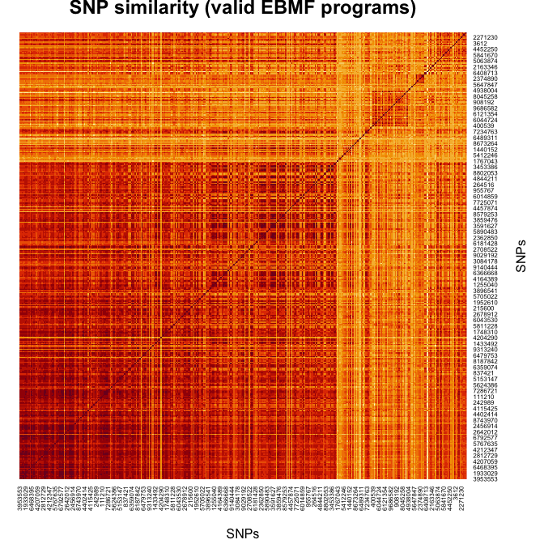

### Program overlap

Because EBMF programs are soft, the same SNP can belong to several programs. The UpSet plot below shows all valid programs, and for every observed intersection how many SNPs are shared by exactly that combination (a Venn diagram generalised to any number of programs). The left-hand bar chart is each program’s size; the dot matrix marks which programs each intersection involves.

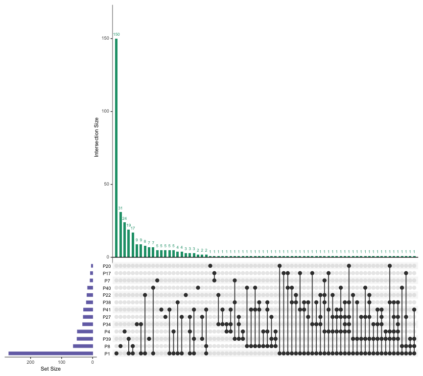

## Step 5: Interpret reliable modules

For each reliable module, rank background traits by **module specificity vs the rest of the trait** (`summarise_module_specific_traits()`), then summarise **trait-category and tissue enrichments vs the trait baseline**, plus pathway hits. `specificity = mean |z| in the module / (mean |z| in the rest + 0.1)` and `abs_mean_z_delta = module - rest` highlight traits that are specifically elevated in this module rather than merely large everywhere (which ranking by `abs_mean_z` alone would over-emphasise). Pathway enrichment is queried across Reactome, KEGG, and Human Phenotype Ontology (HP) with a separate call per source: Reactome and KEGG hits are reported side by side as **pathways**, and HP terms as **phenotypes**, so the three never compete for the same headline.

Trait baseline = all SNPs attributed to this trait in the clustering analysis (`colnames(S)`; for Louvain this equals `names(clusters$cluster)`, and for EBMF it is kept identical so both methods are annotated against the same baseline), using coloc rows for those SNPs only—not the whole GPMap universe. Each module is compared to the **rest of the trait** (leave-one-out): observed link share vs expected share, with fold enrichment.

Annotation tables show the top elevated categories/tissues even when FDR is not significant; FDR is reported when it passes 0.05.

Each hit is scored with a BH-corrected significance summary, thresholded at 0.05:

- **FDR** — hypergeometric test of the module vs the rest of the trait.

The bootstrap `CI` for the fold enrichment shows how precisely the ratio is estimated; because modules are small, a big ratio built on a few links carries a wide interval that includes 1 (the null), so read the CI together with the FDR rather than alone.

### Overview of significant annotations across modules

Top 6 module-specific traits and all significant category, tissue, pathway (Reactome and KEGG separately) and phenotype (HP) hits; n_snps = SNPs in the program, n_unique_snps = SNPs not present in any other program; trait values are specificity scores, and FDR is the BH-corrected hypergeometric enrichment (threshold 0.05)

| group | n_snps | n_unique_snps | module_specific_traits | top_enriched_category | top_enriched_tissue | top_enriched_reactome | top_enriched_kegg | top_enriched_phenotype |
| --- | --- | --- | --- | --- | --- | --- | --- | --- |
| 1 | 270 | 150 | Linoleic acid levels (74.52) Phospholipids to total lipids ratio in very large VLDL (73.31) Treatment/medication code: atorvastatin (70.4) VCAN Plasma pQTL (69.63) Diagnoses - secondary ICD10: E78.0 P… | Socioeconomic Measures (FE=4, FDR=0) Neurological Disease (FE=3.9, FDR=0) Targeted Protein Measure (FE=3.3, FDR=0) Metabolic Disease (FE=3, FDR=0) Disease Of Skin And Subcutaneous Tissue (FE=2.7, FDR=… | none | none | none | none |
| 8 | 62 | 31 | Triglycerides (1.49) Cholesteryl esters to total lipids ratio in medium HDL (1.49) Triglycerides to total lipids ratio in large HDL (1.48) Triglycerides to total lipids ratio in medium HDL (1.41) Trig… | none | Plasma (FE=2.2, FDR=0.0192) | none | Metabolism of xenobiotics by cytochrome P450 (FDR=0.00655) Drug metabolism - cytochrome P450 (FDR=0.0287) Arginine biosynthesis (FDR=0.0489) Drug metabolism - other enzymes (FDR=0.0489) Cholesterol me… | none |
| 39 | 50 | 7 | Number of fluid intelligence questions attempted within time limit (48.7) Intelligence (1.42) Standing height (1.39) Appendicular lean mass (1.32) Sitting height (1.28) Body mass index (UKB data field… | Reproductive Measures (FE=3, FDR=0.00113) | none | none | Cell adhesion molecule (CAM) interaction (FDR=2.92e-05) | none |
| 4 | 49 | 24 | Skin cancer (56.08) Malignant neoplasm of skin (52.24) Cancer of skin (52.24) Forced vital capacity (FVC) (1.48) Height (1.43) Leg predicted mass (right) (1.4) | Reproductive Measures (FE=3, FDR=0.000933) Metabolic Disease (FE=3.1, FDR=0.00358) | none | none | none | none |
| 34 | 32 | 9 | Comparative body size at age 10 (1.84) Appendicular lean mass (1.5) Qualifications: College or University degree (1.42) Basal metabolic rate (1.38) Leg fat-free mass (right) (1.37) Leg predicted mass … | Disease Of Digestive System (FE=3.3, FDR=0.0414) Metabolic Disease (FE=2.9, FDR=0.0414) | none | none | Complement and coagulation cascades (FDR=0.0442) | none |
| 27 | 30 | 5 | Impedance of leg (right) (1.38) Menarche (age at onset) (1.37) Body mass index (BMI) (1.35) Body mass index (UKB data field 21001) (1.34) Comparative body size at age 10 (1.33) Arm fat mass (right) (1… | Reproductive Measures (FE=10, FDR=9.23e-26) | none | none | none | none |
| 41 | 29 | 5 | HDL cholesterol levels (1.52) Waist-to-hip ratio adjusted for BMI (1.41) White blood cell count (eosinophil) (1.31) | none | none | none | Hematopoietic cell lineage (FDR=0.0123) Fluid shear stress and atherosclerosis (FDR=0.0123) | none |
| 38 | 20 | 0 | Height (1.65) Basal metabolic rate (1.63) Whole body fat-free mass (1.61) Whole body water mass (1.61) Arm fat-free mass (right) (1.6) Arm predicted mass (left) (1.6) | none | none | none | Lysosome biogenesis (FDR=0.00124) Glycosaminoglycan degradation (FDR=0.0174) Sphingolipid metabolism (FDR=0.0265) | none |
| 22 | 18 | 3 | Pain type(s) experienced in last month: Knee pain (46.15) Educational attainment (college completion) (1.42) Standing height (1.37) Height (1.36) Qualifications: College or University degree (1.31) Si… | Socioeconomic Measures (FE=13, FDR=9.49e-17) Disease Of Digestive System (FE=5, FDR=0.000322) Psychiatric Measures (FE=4.7, FDR=0.000357) Environmental Measures (FE=6.1, FDR=0.00334) Disease Of Muscul… | none | none | Cell adhesion molecule (CAM) interaction (FDR=0.000158) ECM-receptor interaction (FDR=0.00646) Integrin signaling (FDR=0.00646) | none |
| 40 | 16 | 2 | none | none | none | Interleukin-27 signaling (FDR=0.0134) | none | none |
| 7 | 8 | 5 | Hip circumference (UKB data field 49) (1.41) Arm fat percentage (left) (1.28) | none | none | none | none | none |
| 17 | 7 | 0 | Type 2 diabetes (1.59) Body mass index (BMI) (1.4) Hip circumference (1.4) Hip circumference (UKB data field 49) (1.39) Haemoglobin A1c levels (1.38) Trunk fat percentage (1.31) | none | none | Transcriptional regulation of white adipocyte differentiation (FDR=0.00177) | none | none |
| 20 | 4 | 1 | Basal metabolic rate (1.91) Body mass index (BMI) (1.9) Body mass index (UKB data field 21001) (1.89) Leg predicted mass (left) (1.87) Leg fat-free mass (left) (1.87) Leg fat-free mass (right) (1.86) | none | none | none | none | none |

### Module 1 (270 SNPs)

Module annotations (enrichment vs trait baseline)

| module | trait_categories | tissues | reactome | kegg | phenotypes |
| --- | --- | --- | --- | --- | --- |
| Module 1 (270 SNPs) | **Socioeconomic Measures** (obs=4%, exp=1%, FE=4, CI=[2.2,8.1], FDR=0) **Neurological Disease** (obs=1%, exp=0%, FE=3.9, CI=[0.83,15], FDR=0) **Targeted Protein Measure** (obs=0%, exp=0%, FE=3.3, CI=[… | Brain Hippocampus (obs=1%, exp=1%, FE=1.4, CI=[0.75,2.4]) Cells EBV transformed lymphocytes (obs=2%, exp=2%, FE=1.3, CI=[0.85,2.1]) Brain Spinal cord cervical c 1 (obs=1%, exp=1%, FE=1.2, CI=[0.63,2.3… | none | none | none |

Module-specific traits (specificity >= 1.25; module mean |z| / (rest mean |z| + 0.1))

| trait_name | trait_category | abs_mean_z | abs_mean_z_delta | specificity | mean_z |
| --- | --- | --- | --- | --- | --- |
| Linoleic acid levels | Physiological Measures | 7.452 | 7.452 | 74.52 | -4.383 |
| Phospholipids to total lipids ratio in very large VLDL | Physiological Measures | 7.331 | 7.331 | 73.31 | -3.903 |
| Treatment/medication code: atorvastatin | Metabolic Disease | 7.040 | 7.040 | 70.40 | -7.040 |
| VCAN Plasma pQTL | NA | 6.963 | 6.963 | 69.63 | -1.525 |
| Diagnoses - secondary ICD10: E78.0 Pure hypercholesterolaemia | Metabolic Disease | 6.636 | 6.636 | 66.36 | -6.636 |
| TCTN3 Plasma pQTL | NA | 6.193 | 6.193 | 61.93 | -1.232 |
| Total phospholipid levels in lipoprotein particles | Physiological Measures | 6.127 | 6.127 | 61.27 | -3.184 |
| Liver fat | Physiological Measures | 6.006 | 6.006 | 60.06 | 2.653 |
| Frequency of drinking alcohol | Behavioural Measures | 5.954 | 5.954 | 59.54 | 2.813 |
| Childhood body mass index | Anthropometric Measures | 5.570 | 5.570 | 55.70 | 5.570 |

### Module 17 (7 SNPs)

Module annotations (enrichment vs trait baseline)

| module | trait_categories | tissues | reactome | kegg | phenotypes |
| --- | --- | --- | --- | --- | --- |
| Module 17 (7 SNPs) | Disease Of Genitourinary System (obs=4%, exp=0%, FE=14, CI=[0,83]) Metabolic Disease (obs=11%, exp=2%, FE=5, CI=[0,12]) Disease Of Eye And Adnexa (obs=4%, exp=1%, FE=4.9, CI=[0,20]) | Kidney Cortex (obs=2%, exp=1%, FE=3.1, CI=[0,13]) Artery Coronary (obs=3%, exp=1%, FE=2.8, CI=[0,7.4]) Brain Nucleus accumbens basal ganglia (obs=3%, exp=1%, FE=2.4, CI=[0,6.8]) | Transcriptional regulation of white adipocyte differentiation (FDR=0.00177) | none | none |

Module-specific traits (specificity >= 1.25; module mean |z| / (rest mean |z| + 0.1))

| trait_name | trait_category | abs_mean_z | abs_mean_z_delta | specificity | mean_z |
| --- | --- | --- | --- | --- | --- |
| Type 2 diabetes | Metabolic Disease | 7.743 | 2.958 | 1.59 | -7.743 |
| Body mass index (BMI) | Anthropometric Measures | 7.594 | 2.269 | 1.40 | 7.594 |
| Hip circumference | Anthropometric Measures | 7.872 | 2.344 | 1.40 | 7.872 |
| Hip circumference (UKB data field 49) | Anthropometric Measures | 7.780 | 2.274 | 1.39 | 7.780 |
| Haemoglobin A1c levels | Physiological Measures | 8.591 | 2.478 | 1.38 | -8.591 |
| Trunk fat percentage | Anthropometric Measures | 7.227 | 1.800 | 1.31 | 7.227 |
| Body mass index (UKB data field 21001) | Anthropometric Measures | 6.933 | 1.638 | 1.29 | 6.933 |
| Body fat percentage (UKB data field 23099) | Anthropometric Measures | 6.864 | 1.552 | 1.27 | 6.864 |

### Module 20 (4 SNPs)

Module annotations (enrichment vs trait baseline)

| module | trait_categories | tissues | reactome | kegg | phenotypes |
| --- | --- | --- | --- | --- | --- |
| Module 20 (4 SNPs) | Metabolic Disease (obs=16%, exp=2%, FE=7.1, CI=[0,16]) Disease Of Circulatory System (obs=11%, exp=2%, FE=4.2, CI=[0,11]) Disease Of Digestive System (obs=5%, exp=2%, FE=2.9, CI=[0,9.8]) | Brain Amygdala (obs=6%, exp=1%, FE=6.3, CI=[0,22]) Brain Putamen basal ganglia (obs=6%, exp=1%, FE=4.3, CI=[0,15]) Brain Nucleus accumbens basal ganglia (obs=6%, exp=1%, FE=3.9, CI=[0,13]) | none | none | none |

Module-specific traits (specificity >= 1.25; module mean |z| / (rest mean |z| + 0.1))

| trait_name | trait_category | abs_mean_z | abs_mean_z_delta | specificity | mean_z |
| --- | --- | --- | --- | --- | --- |
| Basal metabolic rate | Physiological Measures | 11.085 | 5.367 | 1.91 | 11.085 |
| Body mass index (BMI) | Anthropometric Measures | 10.317 | 4.998 | 1.90 | 10.317 |
| Body mass index (UKB data field 21001) | Anthropometric Measures | 10.166 | 4.878 | 1.89 | 10.166 |
| Leg predicted mass (left) | Anthropometric Measures | 10.769 | 5.122 | 1.87 | 10.769 |
| Leg fat-free mass (left) | Anthropometric Measures | 10.755 | 5.099 | 1.87 | 10.755 |
| Leg fat-free mass (right) | Anthropometric Measures | 10.662 | 5.025 | 1.86 | 10.662 |
| Leg predicted mass (right) | Anthropometric Measures | 10.673 | 5.020 | 1.86 | 10.673 |
| Impedance of leg (left) | Physiological Measures | 10.218 | 4.782 | 1.85 | -10.218 |
| Arm fat-free mass (left) | Anthropometric Measures | 10.391 | 4.841 | 1.84 | 10.391 |
| Arm predicted mass (left) | Anthropometric Measures | 10.347 | 4.819 | 1.84 | 10.347 |

### Module 22 (18 SNPs)

Module annotations (enrichment vs trait baseline)

| module | trait_categories | tissues | reactome | kegg | phenotypes |
| --- | --- | --- | --- | --- | --- |
| Module 22 (18 SNPs) | **Socioeconomic Measures** (obs=15%, exp=1%, FE=13, CI=[7,23], FDR=9.49e-17) **Infectious Disease** (obs=2%, exp=0%, FE=12, CI=[0,55], FDR=0.0217) **Disease Of Musculoskeletal System And Connective Ti… | Artery Aorta (obs=5%, exp=2%, FE=2.2, CI=[0.46,4.3]) Brain Anterior cingulate cortex BA24 (obs=3%, exp=1%, FE=2.1, CI=[0,4.6]) Plasma (obs=8%, exp=5%, FE=1.8, CI=[0.7,3]) | none | Cell adhesion molecule (CAM) interaction (FDR=0.000158) ECM-receptor interaction (FDR=0.00646) Integrin signaling (FDR=0.00646) | none |

Module-specific traits (specificity >= 1.25; module mean |z| / (rest mean |z| + 0.1))

| trait_name | trait_category | abs_mean_z | abs_mean_z_delta | specificity | mean_z |
| --- | --- | --- | --- | --- | --- |
| Pain type(s) experienced in last month: Knee pain | Disease Of Musculoskeletal System And Connective Tissue | 4.615 | 4.615 | 46.15 | 4.615 |
| Educational attainment (college completion) | Socioeconomic Measures | 5.733 | 1.801 | 1.42 | -4.321 |
| Standing height | Anthropometric Measures | 8.588 | 2.416 | 1.37 | -0.746 |
| Height | Anthropometric Measures | 8.263 | 2.295 | 1.36 | -0.793 |
| Qualifications: College or University degree | Socioeconomic Measures | 5.879 | 1.483 | 1.31 | -4.615 |
| Sitting height | Anthropometric Measures | 7.551 | 1.864 | 1.30 | 3.651 |
| Cognitive performance | Psychiatric Measures | 5.756 | 1.371 | 1.28 | -2.117 |
| Time spent watching television (TV) | Behavioural Measures | 5.840 | 1.351 | 1.27 | 5.840 |

### Module 27 (30 SNPs)

Module annotations (enrichment vs trait baseline)

| module | trait_categories | tissues | reactome | kegg | phenotypes |
| --- | --- | --- | --- | --- | --- |
| Module 27 (30 SNPs) | **Reproductive Measures** (obs=22%, exp=2%, FE=10, CI=[6.6,16], FDR=9.23e-26) Disease Of Genitourinary System (obs=1%, exp=0%, FE=2.6, CI=[0,15]) Socioeconomic Measures (obs=4%, exp=2%, FE=2.4, CI=[0.… | Brain Substantia nigra (obs=2%, exp=1%, FE=2.4, CI=[0.47,5.4]) Vagina (obs=2%, exp=1%, FE=2.1, CI=[0.4,4.8]) Bladder (obs=1%, exp=0%, FE=2, CI=[0,5.8]) | none | none | none |

Module-specific traits (specificity >= 1.25; module mean |z| / (rest mean |z| + 0.1))

| trait_name | trait_category | abs_mean_z | abs_mean_z_delta | specificity | mean_z |
| --- | --- | --- | --- | --- | --- |
| Impedance of leg (right) | Physiological Measures | 7.587 | 2.196 | 1.38 | -7.587 |
| Menarche (age at onset) | Reproductive Measures | 6.072 | 1.740 | 1.37 | -4.868 |
| Body mass index (BMI) | Anthropometric Measures | 7.236 | 1.974 | 1.35 | 7.236 |
| Body mass index (UKB data field 21001) | Anthropometric Measures | 7.133 | 1.907 | 1.34 | 7.133 |
| Comparative body size at age 10 | Anthropometric Measures | 7.661 | 1.998 | 1.33 | 7.661 |
| Arm fat mass (right) | Anthropometric Measures | 7.169 | 1.812 | 1.31 | 7.169 |
| Impedance of leg (left) | Physiological Measures | 7.121 | 1.791 | 1.31 | -7.121 |
| Impedance of arm (left) | Physiological Measures | 7.009 | 1.743 | 1.31 | -7.009 |
| Time spent watching television (TV) | Behavioural Measures | 6.361 | 1.576 | 1.30 | 6.361 |
| Basal metabolic rate | Physiological Measures | 7.462 | 1.802 | 1.30 | 7.462 |

### Module 34 (32 SNPs)

Module annotations (enrichment vs trait baseline)

| module | trait_categories | tissues | reactome | kegg | phenotypes |
| --- | --- | --- | --- | --- | --- |
| Module 34 (32 SNPs) | Mental Disorder (obs=1%, exp=0%, FE=8.2, CI=[0,49]) Environmental Measures (obs=3%, exp=1%, FE=4.1, CI=[0.82,11]) Infectious Disease (obs=1%, exp=0%, FE=4.1, CI=[0,16]) | Uterus (obs=2%, exp=1%, FE=1.9, CI=[0.62,3.9]) Vagina (obs=1%, exp=1%, FE=1.7, CI=[0.54,3.6]) Minor Salivary Gland (obs=2%, exp=1%, FE=1.7, CI=[0.52,3.4]) | none | Complement and coagulation cascades (FDR=0.0442) | none |

Module-specific traits (specificity >= 1.25; module mean |z| / (rest mean |z| + 0.1))

| trait_name | trait_category | abs_mean_z | abs_mean_z_delta | specificity | mean_z |
| --- | --- | --- | --- | --- | --- |
| Comparative body size at age 10 | Anthropometric Measures | 10.797 | 5.037 | 1.84 | 10.797 |
| Appendicular lean mass | Anthropometric Measures | 8.909 | 3.078 | 1.50 | 3.361 |
| Qualifications: College or University degree | Socioeconomic Measures | 7.398 | 2.294 | 1.42 | -7.398 |
| Basal metabolic rate | Physiological Measures | 7.973 | 2.276 | 1.38 | 7.973 |
| Leg fat-free mass (right) | Anthropometric Measures | 7.823 | 2.205 | 1.37 | 7.823 |
| Leg predicted mass (right) | Anthropometric Measures | 7.813 | 2.179 | 1.36 | 7.813 |
| Arm predicted mass (left) | Anthropometric Measures | 7.527 | 2.016 | 1.34 | 7.527 |
| Leg predicted mass (left) | Anthropometric Measures | 7.640 | 2.011 | 1.33 | 7.640 |
| Leg fat-free mass (left) | Anthropometric Measures | 7.645 | 2.007 | 1.33 | 7.645 |
| Arm fat-free mass (left) | Anthropometric Measures | 7.497 | 1.968 | 1.33 | 7.497 |

### Module 38 (20 SNPs)

Module annotations (enrichment vs trait baseline)

| module | trait_categories | tissues | reactome | kegg | phenotypes |
| --- | --- | --- | --- | --- | --- |
| Module 38 (20 SNPs) | Infectious Disease (obs=1%, exp=0%, FE=6.1, CI=[0,49]) Metabolic Disease (obs=7%, exp=2%, FE=3.1, CI=[0.98,6]) Nervous System Disorders (obs=1%, exp=0%, FE=3.1, CI=[0,15]) | Kidney Cortex (obs=1%, exp=1%, FE=2.4, CI=[0,7.3]) Brain Cerebellum (obs=3%, exp=2%, FE=1.6, CI=[0.31,3]) Plasma (obs=7%, exp=5%, FE=1.6, CI=[0.72,2.6]) | none | Lysosome biogenesis (FDR=0.00124) Glycosaminoglycan degradation (FDR=0.0174) Sphingolipid metabolism (FDR=0.0265) | none |

Module-specific traits (specificity >= 1.25; module mean |z| / (rest mean |z| + 0.1))

| trait_name | trait_category | abs_mean_z | abs_mean_z_delta | specificity | mean_z |
| --- | --- | --- | --- | --- | --- |
| Height | Anthropometric Measures | 9.713 | 3.919 | 1.65 | 9.713 |
| Basal metabolic rate | Physiological Measures | 9.309 | 3.705 | 1.63 | 9.309 |
| Whole body fat-free mass | Anthropometric Measures | 9.074 | 3.541 | 1.61 | 9.074 |
| Whole body water mass | Physiological Measures | 9.081 | 3.542 | 1.61 | 9.081 |
| Arm fat-free mass (right) | Anthropometric Measures | 8.762 | 3.399 | 1.60 | 8.762 |
| Arm predicted mass (left) | Anthropometric Measures | 8.751 | 3.380 | 1.60 | 8.751 |
| Arm fat-free mass (left) | Anthropometric Measures | 8.751 | 3.361 | 1.59 | 8.751 |
| Appendicular lean mass | Anthropometric Measures | 8.946 | 3.388 | 1.58 | 8.946 |
| Arm predicted mass (right) | Anthropometric Measures | 8.650 | 3.253 | 1.57 | 8.650 |
| Leg predicted mass (left) | Anthropometric Measures | 8.741 | 3.240 | 1.56 | 8.741 |

### Module 39 (50 SNPs)

Module annotations (enrichment vs trait baseline)

| module | trait_categories | tissues | reactome | kegg | phenotypes |
| --- | --- | --- | --- | --- | --- |
| Module 39 (50 SNPs) | Nervous System Disorders (obs=2%, exp=0%, FE=5.9, CI=[0,24]) Neurological Disease (obs=2%, exp=0%, FE=5.1, CI=[0,20]) Cell Trait (obs=1%, exp=0%, FE=4, CI=[0,24]) | Liver (obs=2%, exp=1%, FE=1.7, CI=[0.4,3.8]) Brain Anterior cingulate cortex BA24 (obs=2%, exp=1%, FE=1.6, CI=[0.35,3.5]) Stomach (obs=3%, exp=2%, FE=1.6, CI=[0.43,3.2]) | none | Cell adhesion molecule (CAM) interaction (FDR=2.92e-05) | none |

Module-specific traits (specificity >= 1.25; module mean |z| / (rest mean |z| + 0.1))

| trait_name | trait_category | abs_mean_z | abs_mean_z_delta | specificity | mean_z |
| --- | --- | --- | --- | --- | --- |
| Number of fluid intelligence questions attempted within time limit | Psychiatric Measures | 4.870 | 4.870 | 48.70 | -1.852 |
| Intelligence | Psychiatric Measures | 6.625 | 2.044 | 1.42 | -1.988 |
| Standing height | Anthropometric Measures | 8.694 | 2.527 | 1.39 | -2.918 |
| Appendicular lean mass | Anthropometric Measures | 7.814 | 1.996 | 1.32 | 2.340 |
| Sitting height | Anthropometric Measures | 7.405 | 1.708 | 1.28 | 1.031 |
| Body mass index (UKB data field 21001) | Anthropometric Measures | 6.674 | 1.462 | 1.26 | 6.674 |

### Module 4 (49 SNPs)

Module annotations (enrichment vs trait baseline)

| module | trait_categories | tissues | reactome | kegg | phenotypes |
| --- | --- | --- | --- | --- | --- |
| Module 4 (49 SNPs) | Neoplasm (obs=2%, exp=0%, FE=4.5, CI=[0,17]) Nervous System Disorders (obs=1%, exp=0%, FE=3.4, CI=[0,12]) **Metabolic Disease** (obs=6%, exp=2%, FE=3.1, CI=[1.5,5.7], FDR=0.00358) | Artery Coronary (obs=2%, exp=1%, FE=1.8, CI=[0.51,3.5]) Artery Aorta (obs=3%, exp=2%, FE=1.5, CI=[0.62,2.6]) Adipose Subcutaneous (obs=4%, exp=2%, FE=1.5, CI=[0.66,2.7]) | none | none | none |

Module-specific traits (specificity >= 1.25; module mean |z| / (rest mean |z| + 0.1))

| trait_name | trait_category | abs_mean_z | abs_mean_z_delta | specificity | mean_z |
| --- | --- | --- | --- | --- | --- |
| Skin cancer | Neoplasm | 5.608 | 5.608 | 56.08 | 5.608 |
| Malignant neoplasm of skin | Neoplasm | 5.224 | 5.224 | 52.24 | 5.224 |
| Cancer of skin | Neoplasm | 5.224 | 5.224 | 52.24 | 5.224 |
| Forced vital capacity (FVC) | Physiological Measures | 7.476 | 2.536 | 1.48 | -4.395 |
| Height | Anthropometric Measures | 8.297 | 2.589 | 1.43 | -2.674 |
| Leg predicted mass (right) | Anthropometric Measures | 7.912 | 2.372 | 1.40 | 7.912 |
| Leg fat-free mass (left) | Anthropometric Measures | 7.852 | 2.291 | 1.39 | 7.852 |
| Leg predicted mass (left) | Anthropometric Measures | 7.839 | 2.287 | 1.39 | 7.839 |
| Trunk fat mass | Anthropometric Measures | 7.627 | 2.178 | 1.37 | 6.660 |
| Leg fat-free mass (right) | Anthropometric Measures | 7.596 | 2.063 | 1.35 | 7.596 |

### Module 40 (16 SNPs)

Module annotations (enrichment vs trait baseline)

| module | trait_categories | tissues | reactome | kegg | phenotypes |
| --- | --- | --- | --- | --- | --- |
| Module 40 (16 SNPs) | Disease Of Genitourinary System (obs=2%, exp=0%, FE=6.8, CI=[0,41]) Neoplasm (obs=2%, exp=0%, FE=4.1, CI=[0,20]) Disease Of Eye And Adnexa (obs=2%, exp=1%, FE=2.4, CI=[0,9.6]) | Brain Cerebellum (obs=4%, exp=2%, FE=2, CI=[0.63,3.9]) Brain Cortex (obs=3%, exp=2%, FE=1.8, CI=[0.39,3.6]) Artery Coronary (obs=2%, exp=1%, FE=1.6, CI=[0,4]) | Interleukin-27 signaling (FDR=0.0134) | none | none |

No traits passed the module-specificity cutoff (specificity >= 1.25).

### Module 41 (29 SNPs)

Module annotations (enrichment vs trait baseline)

| module | trait_categories | tissues | reactome | kegg | phenotypes |
| --- | --- | --- | --- | --- | --- |
| Module 41 (29 SNPs) | Cell Trait (obs=1%, exp=0%, FE=7.3, CI=[0,44]) Metabolic Disease (obs=6%, exp=2%, FE=2.8, CI=[0.79,5.5]) Disease Of Eye And Adnexa (obs=2%, exp=1%, FE=2.7, CI=[0,7.9]) | Cells EBV transformed lymphocytes (obs=4%, exp=2%, FE=2.5, CI=[0.92,4.4]) Plasma (obs=9%, exp=4%, FE=2, CI=[1.2,2.9]) Brain Substantia nigra (obs=1%, exp=1%, FE=1.7, CI=[0,4.5]) | none | Hematopoietic cell lineage (FDR=0.0123) Fluid shear stress and atherosclerosis (FDR=0.0123) | none |

Module-specific traits (specificity >= 1.25; module mean |z| / (rest mean |z| + 0.1))

| trait_name | trait_category | abs_mean_z | abs_mean_z_delta | specificity | mean_z |
| --- | --- | --- | --- | --- | --- |
| HDL cholesterol levels | Physiological Measures | 8.386 | 2.970 | 1.52 | 8.386 |
| Waist-to-hip ratio adjusted for BMI | Anthropometric Measures | 8.120 | 2.458 | 1.41 | -8.120 |
| White blood cell count (eosinophil) | Physiological Measures | 6.153 | 1.555 | 1.31 | 6.153 |

### Module 7 (8 SNPs)

Module annotations (enrichment vs trait baseline)

| module | trait_categories | tissues | reactome | kegg | phenotypes |
| --- | --- | --- | --- | --- | --- |
| Module 7 (8 SNPs) | Disease Of Musculoskeletal System And Connective Tissue (obs=5%, exp=1%, FE=7.8, CI=[0,31]) Environmental Measures (obs=5%, exp=1%, FE=5.4, CI=[0,21]) Disease Of Digestive System (obs=9%, exp=2%, FE=5… | Brain Substantia nigra (obs=3%, exp=1%, FE=3.7, CI=[0,12]) Vagina (obs=3%, exp=1%, FE=3.3, CI=[0,12]) Brain Amygdala (obs=3%, exp=1%, FE=3.2, CI=[0,11]) | none | none | none |

Module-specific traits (specificity >= 1.25; module mean |z| / (rest mean |z| + 0.1))

| trait_name | trait_category | abs_mean_z | abs_mean_z_delta | specificity | mean_z |
| --- | --- | --- | --- | --- | --- |
| Hip circumference (UKB data field 49) | Anthropometric Measures | 7.930 | 2.404 | 1.41 | 7.930 |
| Arm fat percentage (left) | Anthropometric Measures | 7.073 | 1.656 | 1.28 | 7.073 |

### Module 8 (62 SNPs)

Module annotations (enrichment vs trait baseline)

| module | trait_categories | tissues | reactome | kegg | phenotypes |
| --- | --- | --- | --- | --- | --- |
| Module 8 (62 SNPs) | Disease Of Genitourinary System (obs=1%, exp=0%, FE=2.2, CI=[0,13]) Disease Of Eye And Adnexa (obs=1%, exp=1%, FE=1.7, CI=[0,4.8]) Nervous System Disorders (obs=1%, exp=0%, FE=1.7, CI=[0,6.7]) | **Plasma** (obs=10%, exp=4%, FE=2.2, CI=[1.3,3.3], FDR=0.0192) Pancreas (obs=2%, exp=1%, FE=1.8, CI=[0.41,3.7]) Esophagus Mucosa (obs=3%, exp=2%, FE=1.7, CI=[0.64,3.2]) | none | Metabolism of xenobiotics by cytochrome P450 (FDR=0.00655) Drug metabolism - cytochrome P450 (FDR=0.0287) Arginine biosynthesis (FDR=0.0489) | none |

Module-specific traits (specificity >= 1.25; module mean |z| / (rest mean |z| + 0.1))

| trait_name | trait_category | abs_mean_z | abs_mean_z_delta | specificity | mean_z |
| --- | --- | --- | --- | --- | --- |
| Triglycerides | Physiological Measures | 8.785 | 2.991 | 1.49 | -3.068 |
| Cholesteryl esters to total lipids ratio in medium HDL | Physiological Measures | 7.148 | 2.442 | 1.49 | 3.778 |
| Triglycerides to total lipids ratio in large HDL | Physiological Measures | 7.288 | 2.480 | 1.48 | -4.178 |
| Triglycerides to total lipids ratio in medium HDL | Physiological Measures | 7.347 | 2.241 | 1.41 | -3.958 |
| Triglyceride levels in small HDL | Physiological Measures | 7.630 | 2.282 | 1.40 | -4.091 |
| Cholesterol to total lipids ratio in medium HDL | Physiological Measures | 7.126 | 2.123 | 1.40 | 3.794 |
| Triglyceride levels in very small VLDL | Physiological Measures | 7.101 | 2.088 | 1.39 | -3.745 |
| Triglycerides to total lipids ratio in very large HDL | Physiological Measures | 7.421 | 2.160 | 1.38 | -4.128 |
| Free cholesterol to total lipids ratio in medium LDL | Physiological Measures | 6.857 | 1.999 | 1.38 | 3.711 |
| Concentration of chylomicrons and extremely large VLDL particles | Physiological Measures | 6.864 | 1.939 | 1.37 | -3.492 |

## Step 6: Pleiotropy of program-unique vs shared SNPs

Because EBMF programs are soft, a SNP can be assigned to exactly one valid program (**unique**) or to several (**shared**). If programs capture distinct biological programmes, SNPs that uniquely define a single program should be more specific — i.e. carry a lower pleiotropy score (fewer distinct trait categories and protein-coding genes via coloc groups) than SNPs whose signal is shared across programs. We test that here with `get_all_variant_pleiotropies()`.

```
#>
#>
#> Table: Pleiotropy of program-unique vs shared SNPs across valid programs (n = 380 SNPs)
#>
#> |membership_class |metric                                                  | n_snps| mean_pleiotropy| median_pleiotropy|
#> |:----------------|:-------------------------------------------------------|------:|---------------:|-----------------:|
#> |unique           |gene pleiotropy (distinct genes per SNP)                |    242|            3.88|                 1|
#> |unique           |trait-category pleiotropy (distinct categories per SNP) |    242|            2.69|                 2|
#> |shared           |gene pleiotropy (distinct genes per SNP)                |    138|            4.74|                 1|
#> |shared           |trait-category pleiotropy (distinct categories per SNP) |    138|            3.71|                 3|
#>
#>
#> Table: Wilcoxon rank-sum test comparing pleiotropy of unique vs shared SNPs
#>
#> |metric                                                  | wilcoxon_p|
#> |:-------------------------------------------------------|----------:|
#> |trait-category pleiotropy (distinct categories per SNP) |    0.00000|
#> |gene pleiotropy (distinct genes per SNP)                |    0.00945|
```

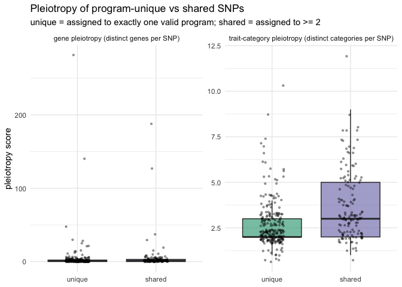